# Freebox 4G debug

Nous allons utiliser `sqldf` pour manipuler les données et `ggplot2` pour les afficher.

```r
library('sqldf')
library('ggplot2')
```

Puis nous chargeons les données générées par `extract_metrics.csv`.

```r
metrics <- read.csv(file="../metrics.csv", header=TRUE, sep=",")
```

## Requêtes sur les données

Chaque minute, un ensemble de metriques est collecté. Voici ce qui a été collecté la première minute :

```r
sqldf('select * from metrics where date = (select date from metrics order by date asc limit 1)')
```

| date | type | name | metric | value |
| --- | --- | --- | --- | --- |
| 2019-07-13T15:59:28.589Z | tunnel | lte | connected | true |
| 2019-07-13T15:59:28.589Z | tunnel | lte | rx_flows_rate | 0 |
| 2019-07-13T15:59:28.589Z | tunnel | lte | tx_flows_rate | 0 |
| 2019-07-13T15:59:28.589Z | tunnel | lte | rx_used_rate | 0 |
| 2019-07-13T15:59:28.589Z | tunnel | lte | tx_used_rate | 0 |
| 2019-07-13T15:59:28.589Z | tunnel | lte | rx_max_rate | 0 |
| 2019-07-13T15:59:28.589Z | tunnel | lte | tx_max_rate | 0 |
| 2019-07-13T15:59:28.589Z | tunnel | xdsl | connected | true |
| 2019-07-13T15:59:28.589Z | tunnel | xdsl | rx_flows_rate | 577 |
| 2019-07-13T15:59:28.589Z | tunnel | xdsl | tx_flows_rate | 157 |

[output cut: 18 more lines]

L’interface de la freebox affiche les données suivantes (extrait depuis le javascript de l’interface) :

```
fieldLabel: 'Lien xDSL',
name: 'tunnel.xdsl.connected',

fieldLabel: 'Débit xDSL Download',
name: 'tunnel.xdsl.rx_used_rate',

fieldLabel: 'Débit xDSL Upload',
name: 'tunnel.xdsl.tx_used_rate',

fieldLabel: 'Lien 4G',
name: 'tunnel.lte.connected',

fieldLabel: 'Débit 4G Download',
name: 'tunnel.lte.rx_flows_rate',

fieldLabel: 'Débit 4G Upload',
name: 'tunnel.lte.tx_flows_rate',
```

Il semble donc que pour la 4G, nous devrions nous concentrer sur `flows_rate` et sur `used_rate` pour le xDSL pour avoir le débit instantané. Il semble que le `max_rate`, qui est le débit maximum du lien, n’ai de sens que pour le xDSL.

À la vue du premier ensemble de données collectées et de leur signification, nous émettons l’hypothèse suivante :

> Hypothèse 1 : Le tunnel 4G a toujours ses valeurs de `flows_rate` à 0 - autrement dit, aucun trafic ne passe jamais par le tunnel 4G

Pour tester cette hypothèse, nous lançons la requête suivante :

```r
lte_above_zero <- sqldf("
  select *
  from metrics
  where type='tunnel'
    and name='lte'
    and metric LIKE '%_flows_rate'
    and value != 0 ")
lte_above_zero
```

| date | type | name | metric | value |
| --- | --- | --- | --- | --- |
| 2019-07-13T21:26:51.907Z | tunnel | lte | rx_flows_rate | 851460 |
| 2019-07-13T21:26:51.907Z | tunnel | lte | tx_flows_rate | 4684 |

L’**Hypothèse 1 est fausse** car nous avons eu un instant où la valeur n’était pas nulle pour le `flows_rate` - le tunnel 4G a donc été utilisé.

Nous allons nous intéresser à la configuration de la radio au moment où la 4G a fonctionné :

```r
lte_up <- sqldf("
  select *
  from metrics
  where type = 'radio'
    and date in (select date from lte_above_zero)")
lte_up
```

| date | type | name | metric | value |
| --- | --- | --- | --- | --- |
| 2019-07-13T21:26:51.907Z | radio | canal 0 | enabled | true |
| 2019-07-13T21:26:51.907Z | radio | canal 0 | bandwidth | 15 |
| 2019-07-13T21:26:51.907Z | radio | canal 0 | rsrq | -8 |
| 2019-07-13T21:26:51.907Z | radio | canal 0 | rsrp | -108 |
| 2019-07-13T21:26:51.907Z | radio | canal 0 | rssi | -81 |
| 2019-07-13T21:26:51.907Z | radio | canal 0 | band | 3 |
| 2019-07-13T21:26:51.907Z | radio | canal 0 | pci | 80 |
| 2019-07-13T21:26:51.907Z | radio | canal 1 | enabled | true |
| 2019-07-13T21:26:51.907Z | radio | canal 1 | bandwidth | 20 |
| 2019-07-13T21:26:51.907Z | radio | canal 1 | rsrq | -14 |

[output cut: 4 more lines]

Nous constatons que les deux canaux sont activés au moment où nous avons eu des données sur le lien 4G.

> Hypothèse 2 : Quand les deux canaux sont activés, les valeurs de `flows_rate` pour la 4G ne sont jamais nulles - autrement dit, quand les deux canaux sont connectés, de la donnée passe forcément sur le tunnel 4G.

Que nous pouvons vérifier à l’aide de la commande suivante :

```r
both_channels <- sqldf("
select distinct metrics.date, IFNULL(l.data_in_tunnel,0) as data_in_tunnel from metrics
  left join (select date, 1 as data_in_tunnel from lte_up) as l on metrics.date = l.date
  where
      metrics.date in (select date from metrics where name = 'canal 0' and value = 'true') and
      metrics.date in (select date from metrics where name = 'canal 1' and value = 'true')
")
both_channels
```

| date | data_in_tunnel |
| --- | --- |
| 2019-07-13T20:57:50.639Z | 0 |
| 2019-07-13T21:26:51.907Z | 1 |
| 2019-07-13T21:27:52.030Z | 0 |
| 2019-07-13T21:32:52.476Z | 0 |
| 2019-07-13T21:37:52.464Z | 0 |
| 2019-07-13T21:42:52.916Z | 0 |
| 2019-07-13T21:47:53.027Z | 0 |

Nous avons donc 6 mesures où les deux canaux sont activés mais où aucune donnée ne transitent par le tunnel. L’**Hypothèse 2** est donc également fausse… Ce qui peut être expliqué par le fait qu’il n’y avait pas beaucoup de trafic à ce moment.

> Hypothèse 3 : Quand les deux canaux ne sont pas activés, les valeurs de `flows_rate` pour la 4G sont toujours nulles - autrement dit, si seulement un canal est activé, le tunnel 4G n’est pas utilisé quoi qu’il arrive.

Bien que nous ayons déjà la réponse, pour exposer les choses clairement :

```r
one_channel <- sqldf("
select distinct date from metrics
  where
      (metrics.date in (select date from metrics where name = 'canal 0' and value = 'false') or
       metrics.date in (select date from metrics where name = 'canal 1' and value = 'false')) and
      metrics.date in (select date from lte_up)
")
one_channel
```

| date |
| --- |

L’**Hypothèse 3** est donc vraie.

## Exploration des données

Les identifiants de bande de fréquences de Free sont (extrait depuis le javascript de l’interface) :

```
xtype: 'enumdisplayfield',
fieldLabel: 'Bande de fréquence',
name: 'radio.bands.0.band',
ttip: 'État du modem 4G',
strings: {
7: '2600 MHz',
3: '1800 MHz',
28: '700 MHz'
}
```

L’antenne à côté de chez moi référence les fréquences suivantes :

- LTE 1750 à 1765 MHz
- LTE 1845 à 1860 MHz
- LTE 2550 à 2570 MHz
- LTE 2670 à 2690 MHz

Comment comparer ces fréquences avec celles affichées dans l’interface de Free ?

Maintenant regardons les fréquences “vues” par notre freebox :

```r
frequencies_map <- data.frame(
  "internal_code" = c(0, 7, 3, 28),
  "pretty_name" = c("Down", "2600 MHz", "1800MHz", "700 MHz")
)

sqldf("
  select
    name as Canal,
    pretty_name as Fréquence,
    count(date) as Occurences
  from metrics, frequencies_map
  where
    metric = 'band' and
    value = internal_code
  group by name,value
")
```

| Canal | Fréquence | Occurences |
| --- | --- | --- |
| canal 0 | 1800MHz | 1118 |
| canal 1 | Down | 1111 |
| canal 1 | 2600 MHz | 7 |

Le canal 0 arrive donc bien à se connecter à la fréquence 1800MHz mais le canal 1 a du mal à maintenir un lien sur le fréquence des 2600 Mhz.

Si on s’intéresse aux différentes métriques d’un lien 4G : RSSI, RSRP et RSRQ seulement pour les occurences où les deux liens étaient fonctionnels, on obtient :

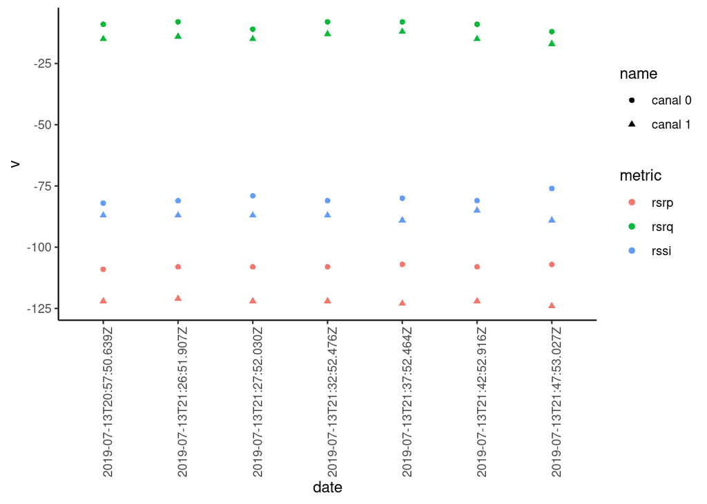

```r
two_channels = sqldf("
  select metric,CAST(value as integer) as v,name,date
  from metrics
  where
      metrics.date in (select date from metrics where name = 'canal 0' and value = 'true') and
      metrics.date in (select date from metrics where name = 'canal 1' and value = 'true') and
      (metric = 'rsrq' or metric = 'rsrp' or metric = 'rssi')
")

ggplot(data = two_channels, aes(x=date, y=v, group=name:metric, color=metric, shape=name)) +
  geom_point() +
  theme_classic() +
  theme(axis.text.x = element_text(angle = 90, hjust = 1))
```

Les valeurs ont l’air stables sur les 7 relevés. Les valeurs du canal 1 semblent toujours un peu en dessous de celles du canal 0, et doit donc être à la limite de la déconnexion.

## Conclusions

Conclusions principales :

1. L’aggrégation 4G n’est utilisée que si les deux canaux sont connectés
2. La Freebox a du mal à se connecter au second canal de fréquence 2600 MHz